# Principal Component Aanalysis Response

Timothy Lee

04/11/2019

## Data

The data you will be using comes from the Assistments online intelligent tutoring system (https://www.assistments.org/). It describes students working through online math problems. Each student has the following data associated with them:

- id
- prior_prob_count: How many problems a student has answered in the system prior to this session
- prior_percent_correct: The percentage of problems a student has answered correctly prior to this session
- problems_attempted: The number of problems the student has attempted in the current session
- mean_correct: The average number of correct answers a student made on their first attempt at problems in the current session
- mean_hint: The average number of hints a student asked for in the current session
- mean_attempt: The average number of attempts a student took to answer a problem in the current session
- mean_confidence: The average confidence each student has in their ability to answer the problems in the current session

## Start by uploading the data

```r
#Probably going to need this
library(tidyverse)
```

```r
#Read in the data
#We won't need the id variable, so remove that.
D1 <- read_csv("Assistments-confidence.csv") %>% select(-id)
```

## Create a correlation matrix of the relationships between the variables, including correlation coefficients for each pair of variables/features.

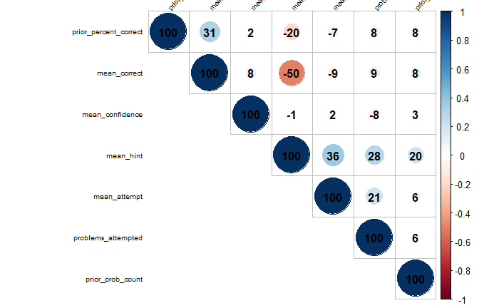

```r
#You can install the corrplot package to plot some pretty correlation matrices (sometimes called correlograms)
library(corrplot)

#Generate pairwise correlations
COR <- cor(D1)

corrplot(COR,
         order = "AOE",
         method = "circle",
         tl.pos = "lt",
         type = "upper",
         tl.col = "black",
         tl.cex = 0.6,
         tl.srt = 45,
         addCoef.col = "black",
         addCoefasPercent = TRUE,
         sig.level = 0.50, insig = "blank")
```

```r
#Study your correlogram image and save it, you will need it later
```

## Create a new data frame with the mean_correct variables removed

```r
D2 <- select(D1, -mean_correct)

#Then, scale and center your data for easier interpretation
D2 <- scale(D2, center = TRUE)
```

## Now run the PCA on the new data frame

```r
pca <- prcomp(D2, scale = TRUE)
```

```r
#$sdev gives the standard deviations of the principal components
pca$sdev
```

```
[1] 1.2825140 1.0543565 1.0245688 0.9621486 0.8556715 0.7320146
```

```r
#To convert this into variance accounted for we can square it, these numbers are proportional to the eigenvalue
pca$sdev^2
```

```
[1] 1.6448423 1.1116675 1.0497412 0.9257299 0.7321737 0.5358454
```

```r
#A summary of our pca will give us the proportion of variance accounted for by each component
summary(pca)
```

```
Importance of components:
                          PC1    PC2    PC3    PC4    PC5     PC6
Standard deviation     1.2825 1.0544 1.0246 0.9621 0.8557 0.73201
Proportion of Variance 0.2741 0.1853 0.1750 0.1543 0.1220 0.08931
Cumulative Proportion  0.2741 0.4594 0.6344 0.7887 0.9107 1.00000
```

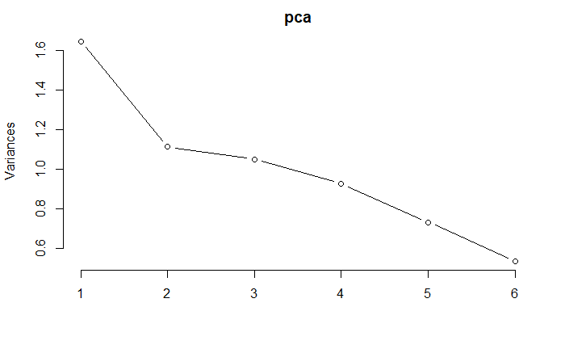

```r
#We can look at this to get an idea of which components we should keep and which we should drop
plot(pca, type = "lines")
```

## Decide which components you would drop and remove them from your data set.

*Probably PC6, but given the next code chunk, I think most would take that back*

## Part II

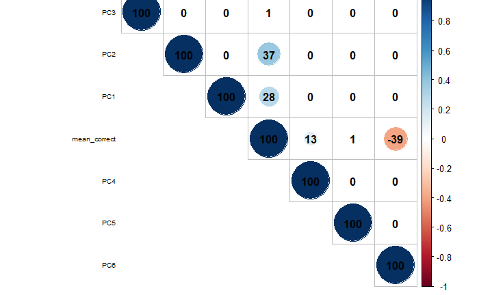

```r
#Now, create a data frame of the transformed data from your pca.

D3 <- data.frame(pca$x)

#Attach the variable "mean_correct" from your original data frame to D3.

D4 <- cbind(D3, as.data.frame(D1$mean_correct)) %>% rename("mean_correct" = "D1$mean_correct")

#Now re-run your scatterplots and correlations between the transformed data and mean_correct. If you had dropped some components would you have lost important infomation about mean_correct?

#Generate pairwise correlations
COR2 <- cor(D4)

corrplot(COR2,
         order = "AOE",
         method = "circle",
         tl.pos = "lt",
         type = "upper",
         tl.col = "black",
         tl.cex = 0.6,
         tl.srt = 45,
         addCoef.col = "black",
         addCoefasPercent = TRUE,
         sig.level = 0.50, insig = "blank")
```